# Day 13: Iterative Forecasting and Process Models

Author

```r
forecast_variable <- "temperature" ###   # Define the forecast variable you want

### ADDING PARAMETER UNCERTAINTY:
# Pseudocode to write the model:

lm_model <- function(air_temperature ,
  uncertainty = TRUE) {

  # Enter in all parameters:
  p1 <- -241.68694
  p2 <- 0.90317 ## <-- include the value here


  # List each of the parameters, include the uncertainty:
  p1_sd <- 6.16417
  p2_sd <- 0.02088


  if (uncertainty) {
    # List each of parameters, adding on the uncertainty:
    p1 <- p1 + rnorm(1,sd = p1_sd)
    p2 <- p2 + rnorm(1,sd = p2_sd)

  }


  # Write down the formula to compute, using all covariates:
  p1 + p2*air_temperature

}

# Now run the model at each location:
neon_site="BARC"
date_to_forecast <- "2024-01-01"
forecast_variables <- "air_temperature"

future <- get_forecast_noaa(site = neon_site,
                            forecast_date = date_to_forecast,
                            met_variables = forecast_variables)

glimpse(future)
```

```
Rows: 25,327
Columns: 6
$ parameter          <dbl> 30, 30, 30, 30, 30, 30, 30, 30, 30, 30, 30, 30, 30,…
$ datetime           <dttm> 2024-01-18 20:00:00, 2024-01-18 21:00:00, 2024-01-…
$ family             <chr> "ensemble", "ensemble", "ensemble", "ensemble", "en…
$ site_id            <chr> "BARC", "BARC", "BARC", "BARC", "BARC", "BARC", "BA…
$ reference_datetime <dttm> 2023-12-31, 2023-12-31, 2023-12-31, 2023-12-31, 20…
$ air_temperature    <dbl> 293.9701, 293.4860, 293.0019, 292.5179, 292.0338, 2…
```

```r
future_target <- future |>
  group_by(parameter) |> # This is the ensemble value
  nest() |>
  mutate(data = map(.x=data,.f=~mutate(.x,
                                       prediction = lm_model(air_temperature,uncertainty = FALSE)
  )
  )
  ) |>
  unnest(cols=c(data)) |>
  mutate(variable = forecast_variable) |>
  select(parameter,datetime,family,site_id,reference_datetime,prediction,variable)
```

## YOUR TURN: Analyzing uncertainty

**NOTE:** This assignment builds off Days 11 - 12 and work done in class on Day 13. Using your model and covariates:

- Compute the process uncertainty.
- Identify the parameter uncertainty.
- Using the target and the information provided in class, what is the initial condition uncertainty?

To do this, you can copy and paste your code from previous assignments, adding in the necessary steps above. Explain your results outside of the code chunk.

Now re-run your forecast including all the uncertainty. Compare your forecast from Day 12 (show the forecast plot) to the new one where uncertainty is included. How did it change / improve / worsen?

```r
forecast_url <- "https://sdsc.osn.xsede.org/bio230014-bucket01/challenges/targets/project_id=neon4cast/duration=P1D/aquatics-targets.csv.gz"

# then run this line to see your targets

forecast_targets <- read_csv(forecast_url, show_col_types = FALSE)

site_year <- 2024
neon_site <- "BARC"

historical_noaa <- noaa_mean_historical(site = neon_site,
                                        year = site_year)

forecast_variable <- "temperature"

noaa_measurement <- "air_temperature"



regression_formula <- temperature ~ 1 + air_temperature

forecast_fit <- fit_lm_model(target_data = forecast_targets,
                             noaa_data = historical_noaa,
                             regression_equation = regression_formula)


summary(forecast_fit)
```

```
Call:
lm(formula = regression_equation, data = data_together)

Residuals:
    Min      1Q  Median      3Q     Max
-8.3075 -1.1343  0.3114  1.3469  6.3930

Coefficients:
                  Estimate Std. Error t value Pr(>|t|)
(Intercept)     -241.68694    6.16417  -39.21   <2e-16 ***
air_temperature    0.90317    0.02088   43.25   <2e-16 ***
---
Signif. codes:  0 '***' 0.001 '**' 0.01 '*' 0.05 '.' 0.1 ' ' 1

Residual standard error: 2.324 on 364 degrees of freedom
Multiple R-squared:  0.8371,    Adjusted R-squared:  0.8366
F-statistic:  1870 on 1 and 364 DF,  p-value: < 2.2e-16
```

```r
broom::augment(forecast_fit)|>
  summarize(sd_process=sd(.resid))
```

```
# A tibble: 1 × 1
  sd_process
       <dbl>
1       2.32
```

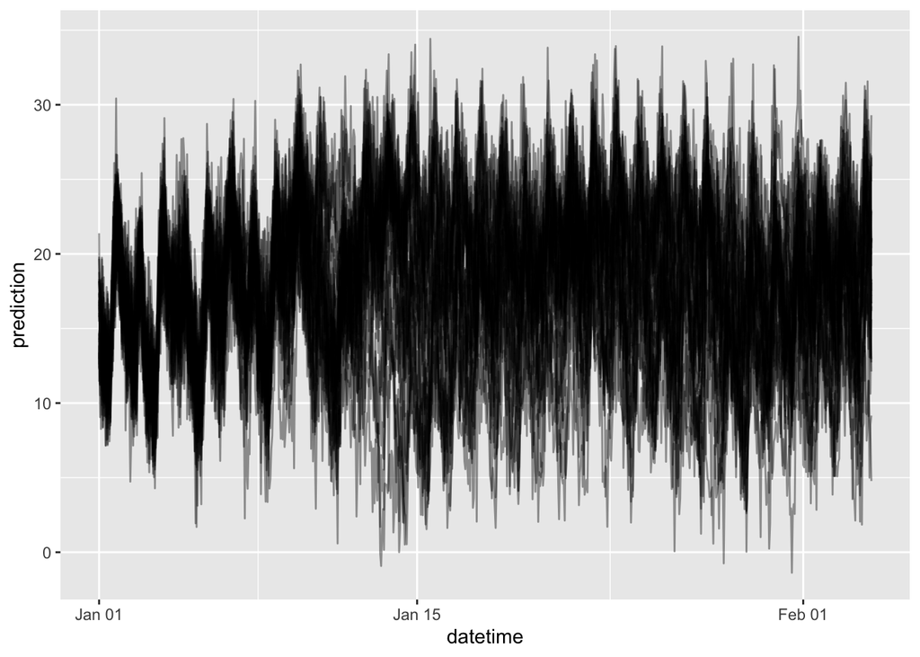

```r
process_sd <- 2.32 ###  # <---- define your process error
  n_obs <- nrow(future_target)  # This counts the rows

# Now add the process error
future_target$prediction <- future_target$prediction + rnorm(n_obs,sd = process_sd)

# Plot the result:
ggplot(data = future_target) +
  geom_line(aes(x=datetime,y=prediction,group=parameter),alpha=0.4)
```

## YOUR TURN: Expand your forecast!

Now choose either:

1. a new forecast target variable
2. a new timeperiod to generate a forecast
3. parameterize your model over a different timeperiod
4. a new site to forecast

Rerun all model steps, analyze the different levels of uncertainty, and evaluate your forecast based on the evaluation metrics we discussed in Day 12.

```r
forecast_variable <- "temperature" ###   # Define the forecast variable you want

### ADDING PARAMETER UNCERTAINTY:
# Pseudocode to write the model:

lm_model <- function(air_temperature ,
  uncertainty = TRUE) {

  # Enter in all parameters:
  p1 <- -269
  p2 <- 1.023 ## <-- include the value here


  # List each of the parameters, include the uncertainty:
  p1_sd <- 11.25
  p2_sd <- 0.04565


  if (uncertainty) {
    # List each of parameters, adding on the uncertainty:
    p1 <- p1 + rnorm(1,sd = p1_sd)
    p2 <- p2 + rnorm(1,sd = p2_sd)

  }


  # Write down the formula to compute, using all covariates:
  p1 + p2*air_temperature

}

# Now run the model at each location:
neon_site="BARC"
date_to_forecast <- "2024-01-01"
forecast_variables <- "air_temperature"

future <- get_forecast_noaa(site = neon_site,
                            forecast_date = date_to_forecast,
                            met_variables = forecast_variables)

glimpse(future)
```

```
Rows: 25,327
Columns: 6
$ parameter          <dbl> 0, 0, 0, 0, 0, 0, 0, 0, 0, 0, 0, 0, 0, 0, 0, 0, 0, …
$ datetime           <dttm> 2024-01-01 00:00:00, 2024-01-01 01:00:00, 2024-01-…
$ family             <chr> "ensemble", "ensemble", "ensemble", "ensemble", "en…
$ site_id            <chr> "BARC", "BARC", "BARC", "BARC", "BARC", "BARC", "BA…
$ reference_datetime <dttm> 2023-12-31, 2023-12-31, 2023-12-31, 2023-12-31, 20…
$ air_temperature    <dbl> 284.7149, 284.1475, 283.5801, 283.0128, 282.6558, 2…
```

```r
future_target <- future |>
  group_by(parameter) |> # This is the ensemble value
  nest() |>
  mutate(data = map(.x=data,.f=~mutate(.x,
                                       prediction = lm_model(air_temperature,uncertainty = FALSE)
  )
  )
  ) |>
  unnest(cols=c(data)) |>
  mutate(variable = forecast_variable) |>
  select(parameter,datetime,family,site_id,reference_datetime,prediction,variable)



forecast_url <- "https://sdsc.osn.xsede.org/bio230014-bucket01/challenges/targets/project_id=neon4cast/duration=P1D/aquatics-targets.csv.gz"

# then run this line to see your targets

forecast_targets <- read_csv(forecast_url, show_col_types = FALSE)

site_year <- 2024
neon_site <- "BARC"

historical_noaa <- noaa_mean_historical(site = neon_site,
                                        year = site_year)

forecast_variable <- "temperature"

noaa_measurement <- "air_temperature"



regression_formula <- temperature ~ 1 + air_temperature

forecast_fit <- fit_lm_model(target_data = forecast_targets,
                             noaa_data = historical_noaa,
                             regression_equation = regression_formula)


summary(forecast_fit)
```

```
Call:
lm(formula = regression_equation, data = data_together)

Residuals:
    Min      1Q  Median      3Q     Max
-8.3075 -1.1343  0.3114  1.3469  6.3930

Coefficients:
                  Estimate Std. Error t value Pr(>|t|)
(Intercept)     -241.68694    6.16417  -39.21   <2e-16 ***
air_temperature    0.90317    0.02088   43.25   <2e-16 ***
---
Signif. codes:  0 '***' 0.001 '**' 0.01 '*' 0.05 '.' 0.1 ' ' 1

Residual standard error: 2.324 on 364 degrees of freedom
Multiple R-squared:  0.8371,    Adjusted R-squared:  0.8366
F-statistic:  1870 on 1 and 364 DF,  p-value: < 2.2e-16
```

```r
broom::augment(forecast_fit)|>
  summarize(sd_process=sd(.resid))
```

```
# A tibble: 1 × 1
  sd_process
       <dbl>
1       2.32
```

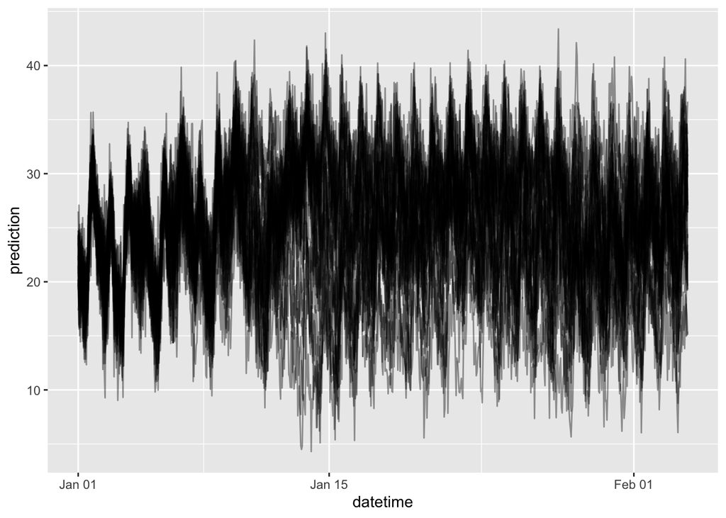

```r
process_sd <- 2.32 ###  # <---- define your process error
  n_obs <- nrow(future_target)  # This counts the rows

# Now add the process error
future_target$prediction <- future_target$prediction + rnorm(n_obs,sd = process_sd)

# Plot the result:
ggplot(data = future_target) +
  geom_line(aes(x=datetime,y=prediction,group=parameter),alpha=0.4)
```

## YOUR TURN: Process models

In class I showed a prompt that explores a possible process model. Copy and paste your prompt with the results below (make sure there are citations!)

## **Gemini Pro:**

### **A Process Model for Temperature with Air Temperature and Downwelling Longwave Flux**

## A process model for temperature that uses **air temperature** and **surface downwelling longwave flux** as inputs is based on the physical principle of **surface energy balance**. This model calculates the temperature of the Earth’s surface by ensuring that all energy inputs and outputs at the surface are equal.

### **The Core Concept: Surface Energy Balance 🌡️**

The model’s foundation is the surface energy balance equation, which states that the net radiation at the surface must be balanced by the other energy fluxes.  
The equation is:  
Rn = H + LE + G

- **Rn** is the **Net Radiation**: The total energy available from all forms of radiation.
- **H** is the **Sensible Heat Flux**: Heat exchanged between the surface and the air through convection and conduction.
- **LE** is the **Latent Heat Flux**: Energy used to evaporate water (a process also known as evapotranspiration).
- **G** is the **Ground Heat Flux**: Heat conducted into the soil or subsurface.

The model works by solving for the **surface temperature (Ts)** that makes this equation balance.  
*(Suggestion: Insert a diagram of the Earth’s surface energy balance here for visual context.)*  
—

### **How Your Inputs Drive the Model**

Your two specified inputs are essential for calculating the key terms in the energy balance equation.

#### **1. Surface Downwelling Longwave Flux (L↓)**

This input is a crucial component of **Net Radiation (Rn)**. It represents the thermal energy radiated downwards from the atmosphere (by clouds, water vapor, etc.) that warms the surface.

- Role: It is a direct energy input in the net radiation calculation:  
  Rn = (Incoming Shortwave - Outgoing Shortwave) + (L↓ - L↑)
- **Context**: The outgoing longwave radiation (L↑) is emitted by the surface itself and is calculated using the surface temperature (Ts) in the Stefan-Boltzmann law: L↑ = ε * σ * Ts^4.

Your downwelling longwave flux input directly determines a major part of the energy gained by the surface.

#### **2. Air Temperature (Ta)**

This input is the primary driver of the **Sensible Heat Flux (H)**, which is the heat transfer between the surface and the air caused by their temperature difference.

- Role: It sets the baseline for heat exchange with the atmosphere. The calculation is:  
  H = ρ * cp * (Ts - Ta) / ra
- **Context**: If the surface is warmer than the air (Ts > Ta), heat flows from the surface to the atmosphere, cooling the surface. If the air is warmer, the surface gains heat. The variables ρ, cp, and ra represent air density, the specific heat of air, and aerodynamic resistance (related to wind), respectively.

**ChatGPT:**

## **Process Model for Temperature with Air Temperature and Surface Downwelling Longwave Flux as Inputs**

### **1. Overview**

A **process model** for temperature aims to predict a temperature variable (e.g., surface temperature) based on environmental drivers. In this case, the covariates are:

- **Air Temperature (T_air)**: The temperature of the air near the surface.
- **Surface Downwelling Longwave Radiation (L↓)**: Longwave radiation emitted downward by the atmosphere, which warms the surface.

### **2. Model Output**

The goal is to model a temperature variable, such as **surface temperature (T_surface)**, as a function of the above inputs.

### **3. Types of Process Models**

#### **a. Empirical (Statistical) Model**

A basic linear regression model might look like:

T_surface(t) = β0 + β1 * T_air(t) + β2 * L↓(t) + ε(t)

Where:

- β0, β1, β2 are regression coefficients.
- ε(t) is a random error term.
- t denotes the time step (e.g., hourly, daily).

This can be extended to nonlinear models using methods like Random Forests or Neural Networks.

#### **b. Mechanistic (Physical) Model**

A more physics-based approach uses the surface energy balance:

C * dT_surface/dt = Rn - H - LE - G

Where:

- C = heat capacity of the surface
- Rn = net radiation
- H = sensible heat flux
- LE = latent heat flux
- G = ground heat flux

Net radiation (Rn) is calculated as:

Rn = L↓ - L↑ + S↓ - S↑

In this context:

- L↓ = downwelling longwave radiation (input)
- T_air affects H (sensible heat exchange with air)

#### **c. Hybrid Model (Physics + Data)**

You can also create a data-driven model informed by physics. For example:

T_surface(t+1) = T_surface(t) + Δt * f(T_air(t), L↓(t))

Where `f` is a learned function (e.g., from a neural network), and Δt is the time step.

### **4. Implementation Tips**

- Ensure consistent units:
  - Temperature in °C or K
  - Radiation in W/m²
- Match the model to your time resolution (hourly, daily, etc.).
- Consider lagged variables if thermal inertia (e.g., in soil) is significant.

### **Summary**

To model surface temperature as a function of:

- **T_air** (Air Temperature)
- **L↓** (Downwelling Longwave Radiation)

You can use:

**Empirical models**:

T_surface = β0 + β1 * T_air + β2 * L↓

2. **Physical models** (energy balance equations)
3. **Hybrid models** (data-driven with physical structure)

**Claude Sonnet 4.5:**

**A process model for water temperature with air temperature as input typically represents the physical heat transfer mechanisms between the atmosphere and a water body. Here are the main approaches:**

## **Simple Energy Balance Model**

**The most fundamental process model is based on heat flux balance:**

**dT_w/dt = (Q_net) / (ρ_w × c_p × h)**

**Where:**

- **T_w = water temperature**
- **Q_net = net heat flux at the water surface**
- **ρ_w = water density**
- **c_p = specific heat capacity of water**
- **h = water depth (for well-mixed systems)**

## **Heat Flux Components**

**Q_net includes several terms driven by air temperature:**

1. **Shortwave radiation (Q_s): Solar radiation (partially dependent on cloud cover, which correlates with air temperature)**
2. **Longwave radiation (Q_l): Both incoming atmospheric radiation (function of air temperature) and outgoing water surface radiation (function of water temperature):**
   - **Q_l,in ∝ εσT_a⁴**
   - **Q_l,out ∝ εσT_w⁴**
3. **Sensible heat flux (Q_h): Heat transfer due to temperature difference:**
   - **Q_h = f(wind) × (T_a - T_w)**
4. **Latent heat flux (Q_e): Heat loss from evaporation, influenced by vapor pressure difference which depends on both air and water temperatures**

## **Simplified Regression Approach**

**For practical applications, empirical models are common:**

**T_w(t) = α × T_a(t) + β × T_w(t-1) + γ**

**This autoregressive form captures the thermal inertia of water while using air temperature as the primary driver.**

## **Equilibrium Temperature Model**

**Another approach uses the concept that water temperature tends toward an equilibrium with air temperature:**

**dT_w/dt = K × (T_eq - T_w)**

**Where T_eq is a function of air temperature and other meteorological variables.**